[figure not shown]

### Master 1 Ingénierie Mathématiques

# Examen : Analyse de données 2

### 27 avril 2019

# Table des matières

I - Exercice 1

- Chargement des bibliothèques nécessaires et des datasets -- Code
- Question 1 : Représentation graphique du visage moyen -- Code
- Question 2 : Réduction par ACP des datasets -- Code
- Question 3 : Représentation graphique d'un visage réduit par ACP -- Code
- Question 4 : Suggestion pour améliorer la complexité de l'ACP
- Question 5 : Implémentation du K plus proche voisin -- Code
- Question 6 : Analyse d'erreur sur les labels prédits -- Code
- Question 7 : Suggestion pour améliorer le modèle -- Code

II - Exercice 2

- Description du dataset
- Nettoyage et optimisation des données -- Code
- Analyse exploratoire des données -- Code
- Analyse factorielle des correspondances -- Code
- Classification Ascendante Hiérarchique -- Code
- Régression Linéaire -- Code
- Validation -- Code

# Exercice 1

### Chargement des bibliothèques et datasets

**Les bibliothèque :** Dans cet exercice nous n'utiliserons que les bibliothèques NumPy (pour la manipulation des tableaux de données), Pandas (pour la gestion des dataframes), Matplotlib (pour afficher des graphiques) et Scikit-Learn (pour effectuer une ACP).

**Les données :** Nous avons quatre datasets à notre disposition, ils sont au format *.csv*. Nous allons donc les charger à l'aide de *read_csv* de la bibliothèque Pandas.  
Remarque : Lors du chargement de données, il est important de préciser qu'il n'y a pas de ligne décrivant les noms des colonnes avec `header=None`. Si l'on ne le précise pas, on perdra le premier visage car il sera considéré comme étant les noms des colonnes.

Code des chargements de bibliothèques et données

### Question 1

**Description des datasets**

Le dataset **TrainI** correspond à un jeu de données d'apprentissage décrivant des visages. Il comporte 320 échantillons (lignes) et 10304 variables (colonnes). Chaque échantillon correspond à un visage et chaque variable à un pixel. Il y a donc 10304 pixels pour chacun des 320 visages. Le dataset **TrainL** décrit les classes de chacun des visages du dataset **TrainI**. Il comporte par conséquent 320 variables en colonnes (les visages) et une ligne (décrivant les classes). Il y a 40 classes numérotées de 1 à 40.  
Le dataset **TestI** correspond à un jeu de données de test décrivant des visages. Il comporte 80 échantillons (lignes) et 10304 variables (colonnes). Chaque échantillon correspond à un visage et chaque variable à un pixel. Il y a donc 10304 pixels pour chacun des 80 visages. Le dataset **TestL** décrit les classes de chacun des visages du dataset **TestI**. Il comporte par conséquent 80 variables en colonnes (les visages) et une ligne (décrivant les classes). Il y a comme pour "TrainL" 40 classes numérotées de 1 à 40.

**Le visage moyen du jeu de données d'apprentissage**

Nous l'avons dit précédemment, dans le dataset **TrainI** chaque ligne est un visage. Afin de représenter graphiquement un visage moyen, il s'agit donc de faire la moyenne de toutes les lignes pour chacun des 10304 pixels (colonnes).

On affiche notre visage à l'aide de `imshow` de Matplotlib qui prend en paramètre un tableau dont les dimensions de ligne et colonne représenteront les dimensions de l'image.  
En effectuant le visage moyen, nous avons un vecteur colonne composé de 10304 colonnes. Pour afficher le visage, nous devons donc redimensionner cette ligne afin créer un tableau dont les lignes et colonnes pourrait raisonnablement représenter la dimension d'une image. Par exemple, la taille d'une photo classique est de 10x15cm. Nous avons 10304 pixels, la dimension raisonnable pour l'image serait donc 112x92 pixels (112x92 = 10304). On utilise la fonction `reshape` de NumPy afin de redimensionner le tableau.  
Remarque : Les valeurs de nos tableaux (formé par reshape et représentant l'image) sont de valeur RVB comprise dans [0,1]. Les couleurs rouge, vert et bleu étant normalement codé par des valeurs comprise entre 0 et 255, il est donc important de préciser dans `imshow` qu'il s'agit de nombre flottant avec `float`.

Nous obtenons le visage moyen suivant :

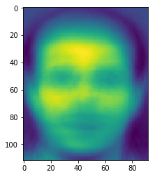

```python
visage_moyen()
```

Code pour l'affichage du visage moyen

On distingue bien les traits d'un visage humain, avec notamment les zones d'ombre (bleu foncé) qui pourrait correspondre aux cheveux et les zones de lumière du visage (jaune).

### Question 2

**Appliquer une ACP**

L'ACP est une analyse factorielle qui permet de produire des facteurs, que l'on appelle les composantes principales et qui sont des combinaisons linéraires des variables initiales. Ainsi, elle transforme les variables corrélées en nouvelles variables décorrélées les unes des autres. Géométriquement, il s'agit de projeter le jeu de données d'un espace de dimensions le nombre de ses variables à un espace de dimensions réduit. Dans notre cas, on va donc projeter notre jeu de données, initialement dans un espace de dimensions 10304, à un espace de dimension 5, 10 et 50.

Dans un premier temps, il faut vérifier s'il est nécessaire de normaliser notre jeu de données : il s'agit de regarder si les moyennes et écarts types sont globalement équivalent pour chaque pixel. Si ce n'est pas le cas, l'utilisation de la fonction `StandartScaler` de Scikit_learn est nécessaire. On constate, grâce au code d'analyse de la moyenne et écart type, que ces derniers sont globalement équivalent pour toutes les variables. Il n'est donc pas nécessaire d'utiliser la fonction `StandartScaler`.  
La réduction de dimension s'effectue en deux temps, tout d'abord, à l'aide de la fonction `PCA` de Scikit_learn, on créé l'objet "transformateur" prenant en paramètre la nouvelle dimension souhaité. Finalement, on ajuste le modèle avec le dataset **TrainI** et on applique la réduction de dimensionnalité sur celui ci à l'aide de `fit_transform`.  
On peut visualiser les nouvelles données réduite en le convertissant en `DataFrame`.

Pour visualiser les DataFrames et le code : Code de l'application de l'ACP

### Question 3

**Représenter graphiquement un visage pour chaque réduction par ACP**

Comme nous l'avons vu dans la question précédent l'ACP consiste à réduire la dimensionalité de l'espace de fonctions et à fouiller dans cet espace de fonctions réduit. Dans la plupart des cas et comme nous l'avons vu en cours, il s'agit plus précisement d'identifier les dimensions les plus importantes et n'en garder que quelques-unes pour expliquer l'essentiel de la variance observée et donc conserver le plus d'informations possible.  
Cependant dans notre cas où l'on étudie des images, il s'agit plutôt d'identifier les variables les plus importantes et qui contribuent le plus aux composantes principales puis à se demander à quoi ressemblerait nos images dans notre espace initial mais qu'avec la contribution des variables importantes. Pour répondre à cette question, on utilise l'inversion du PCA de Scikit-Learn avec la fonction `inverse_transform`. Cette fonction consiste à transformer les données pour un retour à leur espace d'origine.  
Remarque : Une autre manière de transformer les données réduit à leur espace d'origine est de multiplier ces derniers par la matrice de vecteurs propres du PCA.  
Ce retour à l'espace originel permet lorsque l'on affiche le plot d'observer globalement la quantité d'informations conservé, plus l'image est net plus l'on a conservé d'informations grâce aux composantes principales et plus l'image est flou plus l'on a perdu d'informations.

Finalement, comme pour la question 1, on affiche notre visage à l'aide de `imshow` de Matplotlib qui prend en paramètre le tableau redimensionné par `reshape` de NumPy.

**Réduction à une dimension k=5** : Code

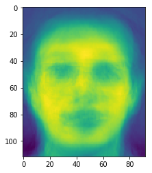

```python
visage_acp5()
```

**Réduction à une dimension k=10** : Code

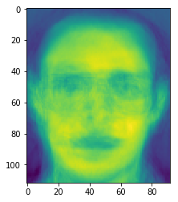

```python
visage_acp10()
```

**Réduction à une dimension k=50** : Code

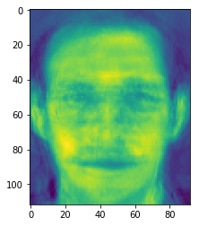

```python
visage_acp50()
```

**Le vrai visage sans réduction en ACP** : Code

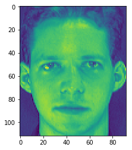

```python
vrai_visage()
```

On constate une assez bonne approximation pour une réduction à 50 (notons que les données initiales sont de dimensions 10304).

### Question 4

Nous travaillons avec des visages humains et nous avons des données d'une dimension de 10304 (112 x 92 pixels) pour leur reconnaissance. Or, nous avons constaté avec le visage moyen que les visages humains se ressemblent un peu alors on peut facilement penser que les échantillons reposent en vérité sur une variété de dimensions beaucoup plus basse que 10304. Ainsi, la fonction `PCA()` utilisé avec le paramètre `svd_solver='randomized'` peut être très utilse dans ce cas, car elle va permettre de supprimer la plupart des vecteurs singuliers et ainsi limiter le calcul à une estimation approximative des vecteurs singuliers que nous conserverons pour la transformation.

Par ailleurs, dans certains cas où les données sont tellement volumineuse qu'elles ne peuvent être en totalité disponible avant et lors du traitement de l'ACP, on peut utiliser l'ACP incrémentale. Le principe de l'ACP incrémentale est d'intégrer les colonnes une à une dans le calcul. Ce n'est pas le cas ici car nos données peuvent très largement tenir en mémoire, mais cela peut être le cas pour des bases de données très volumineuse.

### Question 5

**Principe du K plus proche voisin :**  
Il s'agit de chercher, parmi le jeu de données d'apprentissage, les K plus proche voisins au sens d'une dissimilarité (ici on choisira la distance euclidienne) de chaque nouvel échantillon d'un jeu de données test. On détermine ensuite pour chaque groupe de voisins, le label (classe) le plus représenté dans le groupe, ce label est ensuite affecté comme label de l'échantillon test du groupe de voisins étudié. Finalement chaque donnée du test possèdera un label prédit. On pourra ensuite comparer les labels prédit aux véritable labels du jeu de données test.

Dans notre cas, nous voulons effectuer le modèle du k plus proche voisin au jeu de données réduit par ACP. Il s'agit donc de :

- effectuer une ACP pour le dataset **TestI** afin que les dimensions correspondent au dataset réduit de **TrainI**. Ceci est indispensable sinon il est impossible de calculer les distances euclidiennes.
- Pour chacun des 80 visages (lignes) du dataset réduit **TestI**, rechercher les K plus proche voisins dans le dataset réduit par ACP, **skl_pca**. Pour chaque visage, une liste des k plus proche voisins sera créée.
- Pour chaque liste de voisins, affecter à chaque voisin de la liste son label que l'on trouve dans le dataset **TrainL**.
- Créer un compteur, compter et trouver le label le plus représenter dans la liste de voisin, ce label est finalement affecté au visage étudié du dataset **TestI**.
- On obtiendra finalement pour chacun des 80 visages un label prédit.

À ma connaissance, il n'y a pas de fonction permettant de calculer la distance euclidienne entre 2 échantillons. Nous allons donc commencer par l'implémenter. On implémente ensuite une deuxième fonction qui consiste à établir une liste des k plus proche voisin d'un visage donnée en paramètre (ie une ligne de TestL) avec le k. Cette fonction utilisera la fonction de la distance euclidienne implémenté juste avant. Finalement, on implémente une dernière fonction prediction qui utilisera la fonction des k plus proche voisin et consistera à prédire le label pour un certain visage.

Nous allons tester cette algorithme avec une recherche des 5 plus proche voisins et afficher le résultat pour les quelques premiers visage :

```python
afficheLabel(10,5)
```

```
Visage 1 :
Label prédit :10 | Vrai label : 1
Visage 2 :
Label prédit :10 | Vrai label : 1
Visage 3 :
Label prédit :4 | Vrai label : 2
Visage 4 :
Label prédit :4 | Vrai label : 2
Visage 5 :
Label prédit :9 | Vrai label : 3
Visage 6 :
Label prédit :4 | Vrai label : 3
Visage 7 :
Label prédit :4 | Vrai label : 4
Visage 8 :
Label prédit :4 | Vrai label : 4
Visage 9 :
Label prédit :7 | Vrai label : 5
Visage 10 :
Label prédit :7 | Vrai label : 5
```

Code du Kppv implémenté

On constate déjà avec les premiers visage que le kppv n'est pas très performant car sur 10 visage, il n'a réussi à prédire correctement que les labels de 2 visages. Nous allons calculer le taux exact d'erreurs de ce modèle.

### Question 6

Pour l'analyse d'erreurs, nous implémenterons une fonction simple qui consistera à compter le nombre de labels qui ne corresponderaient pas aux vrais labels du dataset **TestL**.

Pour les k plus proche voisin effectué avec k=5, à partir des données réduites par ACP, on obtient le taux d'erreurs suivant :

```python
analyseErreurs(5)
```

```
Proportion d'erreurs pour k =5 : 0.975
```

Code de l'analyse d'erreurs

On constate que le modèle a un taux d'erreurs très proche de 1, cela veut dire qu'il n'a réussi à prédire correctement que très peu de labels (exactement 2 labels sur 80).

### Question 7

Le fait que d'effectuer le k plus proche sur le dataset réduit par ACP à l'air de fausser la prédiction des labels, car lorsque l'on effectue le k plus proche voisin sur le dataset original, on constate qu'il y a un faible taux d'erreurs, la prédiction est donc bonne. Tandis qu'avec le dataset réduit par ACP la prédiction est très mauvaise. Cependant, la compléxité du Kppv appliqué au dataset original augmente considérablement à cause du calcul de la distance euclidienne, cela peut prendre 5 à 10 minute avant d'obtenir un résultat.

**Résultat de la prédiction des 10 premiers visage avec le dataset original :**

```python
afficheLabel2(10,5)
```

```
Visage 1 :
Label prédit :1 | Vrai label : 1
Visage 2 :
Label prédit :1 | Vrai label : 1
Visage 3 :
Label prédit :2 | Vrai label : 2
Visage 4 :
Label prédit :2 | Vrai label : 2
Visage 5 :
Label prédit :3 | Vrai label : 3
Visage 6 :
Label prédit :3 | Vrai label : 3
Visage 7 :
Label prédit :4 | Vrai label : 4
Visage 8 :
Label prédit :4 | Vrai label : 4
Visage 9 :
Label prédit :5 | Vrai label : 5
Visage 10 :
Label prédit :18 | Vrai label : 5
```

```python
analyseErreurs2(5)
```

```
Proportion d'erreurs pour k = 5 : 0.075
```

Code du kppv sur données original

On pourrait améliorer le modèle en faisant de la **validation croisée** sur les données d'apprentissage. Le fait d'utiliser la validation croisée sur les données d'apprentissage va nous permettre de choisir le modèle qui a la meilleure performance. Puis une fois le modèle sélectionné on pourra l'appliquer à nos données de test pour la prédiction. Il peut aussi être utile dans le cas d'un modèle de k plus proche voisin d'effectuer une recherche sur grille (Grid search). Cela consiste à créer une grille d’hyperparamètres (ici l'hyperparamètre est k), contenant plusieurs valeurs possibles pour chacun d’entre eux, que l’on explore pour tester toutes les combinaisons possibles. Lors de la validation croisé nos données doivent être stratifié car lorsque l'on regarde le dataset des labels, on constate que les labels sont rangés en groupe donc afin de ne pas biaiser la validation nous devons stratifié nos données pour la création de folds (plis) lors de la validation (cela est fait automatiquement dans le code utilisé mais d'un point de vue théorique il est important de le préciser). On pourra ensuite appliqué le modèle sur nos données test.  
À noter : l'utilisation de la fonction `GridSearchCV` nécessite obligatoirement l'utilisation du `KNeighborsClassifier` de scikit-learn. On pourra récuperer l'hyperparamètre estimé pour l'appliqué à notre kppv implémenté.

Remarque : On appelle hyperparamètre les paramètres de l’algorithme d’apprentissage qui va nous permettre de déterminer le modèle.

```python
gridSearch()
```

```
Résultats de la validation croisée :
accuracy = 0.91875 pour k = {'n_neighbors': 3}
accuracy = 0.8625 pour k = {'n_neighbors': 5}
accuracy = 0.734375 pour k = {'n_neighbors': 10}
accuracy = 0.665625 pour k = {'n_neighbors': 15}
accuracy = 0.6125 pour k = {'n_neighbors': 20}
accuracy = 0.559375 pour k = {'n_neighbors': 30}
accuracy = 0.45625 pour k = {'n_neighbors': 40}
accuracy = 0.365625 pour k = {'n_neighbors': 50}
Meilleur hyperparamètre :{'n_neighbors': 3}
Proportion de prédiction correct sur TestI : 0.9375
```

Ainsi le meilleur hyperparamètre serait le 3.

Code pour la recherche sur grille

**Application de l'hyperparamètre estimé à notre fonction Kppv implémenté pour le dataset réduit par ACP :**

```python
analyseErreurs(3)
```

```
Proportion d'erreurs pour k = 3 : 0.975
```

On constate que cela n'a pas spécialement améliorer notre prédiction.

Le **bootstrap** peut également être envisageable, il est cependant assez complexe de le mettre en place dans ce cas précis.

# Exercice 2

## Description du dataset

Le dataset choisi contient les informations de 9551 restaurants répartie dans le monde entier. À travers ses 21 variables, il décrit principalement la localisation, le service, la qualité, le prix et l'appréciation des différents restaurants.  
Le but de cette exercice sera dans un premier temps d'effectuer une analyse exploratoire des données afin de se familiariser aux données et pouvoir développer quelques intuitions. Dans un second temps, nous effectuerons toute une série de méthodes de Machine Learning afin d'en apprendre davantage sur la manière dont les restaurants ont été noté.

```python
df.info()
```

```
<class 'pandas.core.frame.DataFrame'>
RangeIndex: 9551 entries, 0 to 9550
Data columns (total 21 columns):
Restaurant ID           9551 non-null int64
Restaurant Name         9551 non-null object
Country Code            9551 non-null int64
City                    9551 non-null object
Address                 9551 non-null object
Locality                9551 non-null object
Locality Verbose        9551 non-null object
Longitude               9551 non-null float64
Latitude                9551 non-null float64
Cuisines                9542 non-null object
Average Cost for two    9551 non-null int64
Currency                9551 non-null object
Has Table booking       9551 non-null object
Has Online delivery     9551 non-null object
Is delivering now       9551 non-null object
Switch to order menu    9551 non-null object
Price range             9551 non-null int64
Aggregate rating        9551 non-null float64
Rating color            9551 non-null object
Rating text             9551 non-null object
Votes                   9551 non-null int64
dtypes: float64(3), int64(5), object(13)
memory usage: 1.5+ MB
```

## Nettoyage et optimisation des données

Dans cette partie, nous réaliserons tout un ensemble de manipulations afin de préparer au mieux le dataset pour l'analyse exploratoire des données.

### Gestion des valeurs manquantes

Seul la variable "Cuisines" possède des valeurs manquantes au nombre de 9 (voir ici). Ceci est rassurant. Les restaurants n'ayant pas d'indication sur la cuisine servi pourront être supprimer ultérieurement si nécessaire, mais ils ne le seront pas du dataset principal car ils pourront être utile pour les autres variables.

### Décodage de la variable Country Code

La variable "Country Code" contient les pays représenté par un nombre. Cependant, nous ne savons pas à quel pays correspond tel nombre.  
Pour résoudre ce problème, nous pouvons utiliser les variables "Latitude" et "Longitude" ainsi que la bibliothèque `folium`, interface entre python et la librairie leaflet. Le package `folium` nous permet de placer sur une carte des coordonnées géographique.

Nous allons tout d'abord créer une liste contenant des sous listes d'indices des restaurants ayant le même code-pays (et qui sont par conséquent localisés dans le même pays). Cette liste nous est utile afin de récuperer l'indice d'un restaurant de chaque sous-liste. Dans chaque sous liste, le restaurant est choisi arbitrairement et répresentera donc son pays pour tous les autres restaurants de sa liste. Une fois les indices récuperés, on en récuperera les coordonnées géographiques de chacun dans le dataset principal et on affichera un popup le représentant sur la carte.  
Sur la carte, afin de savoir à quel code correspond un point, il suffit de cliquer sur le popup. Il sera maintenant facile de repérer à quel pays correspond chaque popup en zoomant et en lisant le nom de pays.

Remarque : Les explications de code sont fait plus en détails en commentaire dans chaque bloc de code.

```python
monde
```

[interactive chart not shown]

Code pour la cartographie

Voici donc à quel pays correspond chaque code :

```python
Country_Code_Name
```

|  | Country Code | Country Name |
| --- | --- | --- |
| 0 | 162 | Philippines |
| 1 | 30 | Brésil |
| 2 | 216 | USA |
| 3 | 14 | Australie |
| 4 | 37 | Canada |
| 5 | 184 | Singapour |
| 6 | 214 | EAU |
| 7 | 1 | Inde |
| 8 | 94 | Indonésie |
| 9 | 148 | Nouvelle Zelande |
| 10 | 215 | RU |
| 11 | 166 | Qatar |
| 12 | 189 | Afrique du Sud |
| 13 | 191 | Sri Lanka |
| 14 | 208 | Turquie |

Nous pouvons aussi rajouter la colonne "Country Name" dans notre dataset principal. Mais par mesure de sécurité sur les données, nous ne modifierons pas le dataset principal mais nous en effectuerons une copie auquel nous ajouterons la colonne.

### Conversion des prix moyen en dollars américain

On constate en parcourant certaine ligne du dataframe que certains prix ont l'air exhorbitant par rapport à d'autre. Cela est dû au fait qu'il ne sont pas tous exprimé avec la même devise. Chaque prix est exprimé selon la monnaie local. Ainsi pour une analyse non biaisé par cela, nous allons convertir tous les prix en une unique monnaie, le dollars américain. Le tableau ci dessous répertorie la taux de change en dollars pour chaque monnaie :

```python
ConvertCurrency
```

|  | Currency | To Convert dollars |
| --- | --- | --- |
| 0 | Botswana Pula(P) | 0.019000 |
| 1 | Brazilian Real(R$) | 0.250000 |
| 2 | Dollar($) | 1.000000 |
| 3 | Dollar($) | 0.720000 |
| 4 | Dollar($) | 0.750000 |
| 5 | Dollar($) | 0.740000 |
| 6 | Emirati Diram(AED) | 0.270000 |
| 7 | Indian Rupees(Rs.) | 0.014000 |
| 8 | Indonesian Rupiah(IDR) | 0.000071 |
| 9 | NewZealand($) | 0.670000 |
| 10 | Pounds(£) | 1.300000 |
| 11 | Qatari Rial(QR) | 0.270000 |
| 12 | Rand(R) | 0.071000 |
| 13 | Sri Lankan Rupee(LKR) | 0.005700 |
| 14 | Turkish Lira(TL) | 0.170000 |

Code pour la conversion

### Création de catégories de prix

Etant donnée la grande variété de prix, il pourrait également être utile de créer des catégories de prix. On créé donc 4 catégories : [0,30], [30,60], [60,100] et [100,+].

Code pour les catégories de prix

## Analyse exploratoire des données

Le but de cette section est de regarder graphiquement si des informations interessantes sont à souligner.

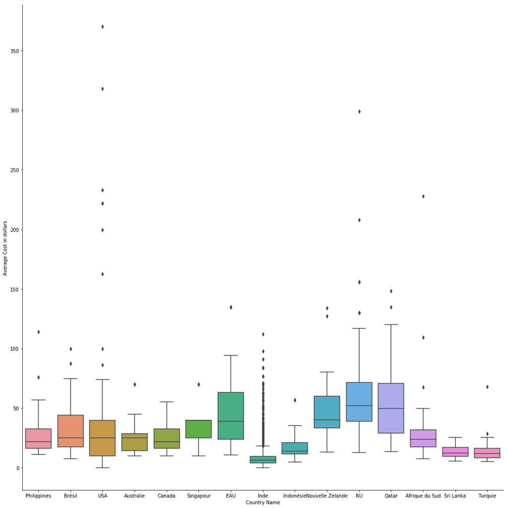

```python
boxplot1()
```

Code pour le graphe

D'après ce graphique, on constate que les pays ont une gamme de prix plus ou moins large. Mais certains pays, comme l'Inde, le Sri-Lanka et la Turquie se démarque par leur prix qui reste toujours assez bas.

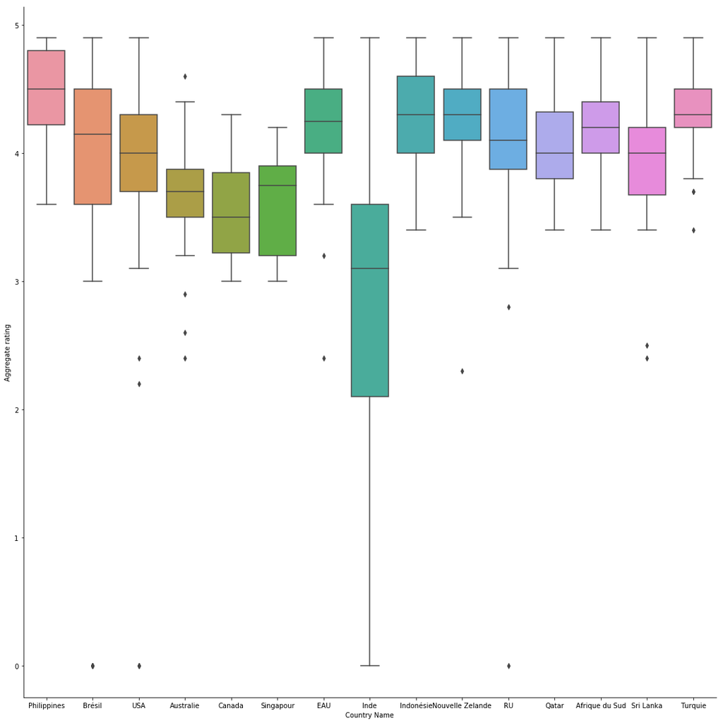

```python
boxplot2()
```

Code pour le graphe

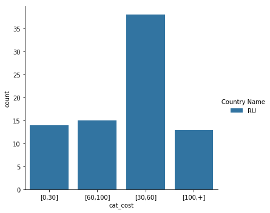

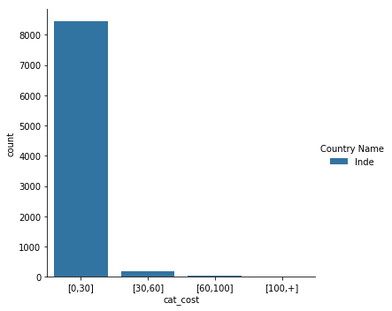

```python
histo1()
```

Code pour le graphe

Ces graphes confirme que certain pays peuvent avoir de grande différence. L'inde ne propose pratiquement que des repas compris entre 0 et 30 dollars, tandis que pour le royaume unis une grande partie de leurs restaurants propose des pour plus de 30 dollars.

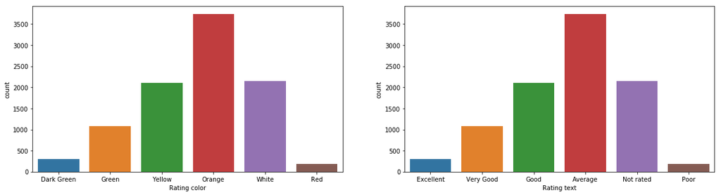

```python
barplot1()
```

Code pour le graphe

On constate ici que ce sont exactement les mêmes graphe à l'exception que l'un concerne la notation en couleur et l'autre en appréciation. Un coïncidence sur les proportions exacte de part et d'autre serait très surprenant. Il semblerait en effet qu'il y ai une correspondance exacte entre les couleurs et les appréciations.

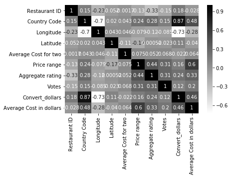

```python
graphcorr()
```

Code pour le graphe

Finalement, on affiche le graphe des corrélations entre les variables, certaine case foncés se distingue comme "Price range" avec "Average Cost in dollars"

## Analyse factorielle des correspondances

L’Analyse Factorielle des Correspondances permet de résumer et de visualiser l’information contenue dans un dataframe formé par des variables catégorielles. L’AFC retourne des coordonnées appelé "factor score". Celle ci sont évalué, par des calcul de fréquence, à partir d'un tableau où les variable catégorielle ont été transformé en variable indicatrice (on obtient ce tableau à l'aide de la fonction `get_dummies`). Ces coordonnées permettent finalement de visualiser graphiquement l’association entre les variables à deux dimensions dans un nuage de points.

Remarque : Si les variables catégorielles ne présente pas plus de deux modalités, la fonction `get_dummies` n'est pas nécessaire.

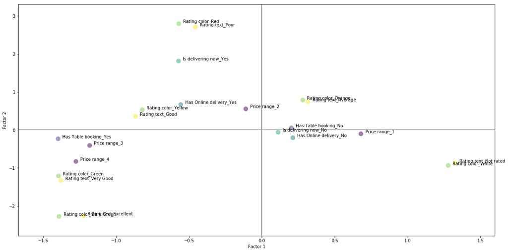

```python
afc()
```

Code pour l'AFC

On constate que chaque couleur de notation correspond exactement à une appréciation (sans le jitter les points se superposent). La couleur blanche correspond à l'appréciation "not-rated" (pas d'appréciation), la couleur orange correspond à l'appréciation "average" (moyen), la couleur rouge correspond à l'appréciation "poor" (mauvais), la couleur jaune correspond à l'appréciation "good" (bon), la couleur vert foncé correspond à l'appréciation "excellent", la couleur vert correspond à l'appréciation "very good" (très bon).

On peut par ailleurs associé la tranche de prix 4 et 3 à l'appréciation excellent et très bon. On peut supposer que ce sont des tranches de prix élévés. Tandis que la tranche de prix 1 est plutôt associé au manque d'appréciation (not rated) et à l'appréciation moyen. L'appréciation mauvais est davantage associé à la tranche de prix 2.

On remarque aussi que la réservation des tables concerne les tranches de prix 3 et 4.

Il y a donc pas mal d'informations à tirer de ce graphique.

## Classification Ascendante Hiérarchique

Le but de Classification Ascendante Hiérarchique est de répartir les différents restaurants selon un certain nombre de classe à partir de la moyenne des notes obtenues et de leur nombre. Le dataset étant assez volumineux, nous allons réaliser cette classification sur la base d'un pays, les USA avec leurs 434 restaurants.

Nous effectuons une CAH selon le critère de Ward à l'aide de la fonction `dendrogram` de la bibliothèque scipy.cluster.hierarchy.

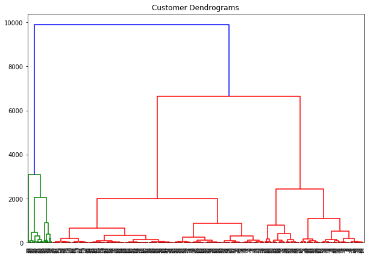

```python
graph_dendrogram()
```

Code du dendrogramme

Sur le dendogramme, que nous pouvons observer, nous distinguons 3 classes. En affectant à chaque restaurant sa classe correspondante avec la fonction `AgglomerativeClustering` de la bibliothèque sklearn.cluster, nous pouvons réaliser un nuage de points avec d'observer ces différentes classe.

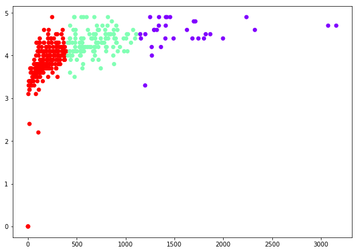

```python
clustering()
```

Code du graphe

On constate que les classes ont été réalisé uniquement sur la base du nombre de votant car les notes sont assez bonne pour tous les restaurant (globalement compris entre 3/5 et 5/5), il n'y a donc pas de classe réalisé sur la base des notes.

## Régression Linéaire

Lorsqu'un client affecte une note à un restaurant, nous pensons que le prix payé influence la note donnée.  
Pour estimer l'influence du prix sur la notation, nous allons effectuer une régression linéaire entre les variables "Average rating" et "Average Cost in dollars" qui est la variable créé à partir de "Average Cost for two" et qui correspond au prix moyen en dollars. Nous n'aurions pas pu effectuer la régression linéaire sur la variable "Average Cost for two" car les devises change d'un pays à l'autre et l'ordre de grandeur qui diffère peut biaisé notre modèle.  
Nous avons utilisé la fonction `LinearRegression` de la bibliothèque Scikit-Learn.  
À l'issue de cette régression linéaire nous obtenons les coefficients suivant :

```python
estimateur()
```

```
Valeur du coefficient de la variable explicative : [0.0334657]
Valeur de l'intercept (ordonnée à l'origine) : 2.2946285610825097
```

Code de la régression linéaire

**Interprétation** :  
Avec les estimateurs, on obtiendrai donc le modèle linéaire suivant  
Note = 2.29 + 0.033 * Prix

Cela veut dire que sans l'influence du prix, la note attribué serait de 2.29 et la note augmenterait de 0.033 par dollars payé. Par exemple, si le prix de notre repas s'élève à 30 dollard la note de 1 point.

Il est évident que le modèle est trop simple afin d'expliquer la notation des restaurants, il faudrait prendre en compte d'autres regresseurs non disponible dans nos données. Nous allons d'ailleurs le constater avec la validation et pénalisation du même modèle.

## Validation

Nous venons de réaliser une régression linéaire et avons obtenu des estimateurs des coefficients du modèle. Le but de la validation est de calculer la racine de l'erreur quadratique moyenne et l'erreur absolu moyenne des paramètres afin de caractériser leur précision. L'erreur quadratique moyenne est la moyenne arithmétique des carrés des écarts entre les prévisions du modèle et les observations. Il s'agit donc de la valeur à minimiser dans le cadre d’une régression simple. L'erreur absolu moyenne est la moyenne arithmétique des valeurs absolues des écarts.

Voici les erreurs obtenues :

```python
afficheErreurs()
```

[output not shown]

Code pour la validation

On obtient des erreurs comprise entre 1 et 1.5. Etant donnée que la notation se fait de 0 à 5, les erreurs restent assez élevé. Les estimations du modèle sont donc peu précise.  
Cela n'est pas étonnant vu la simplicité du modèle.

On aurait d'ailleurs pu, si l'on avait plus de variables à notre disposition, effectuer des regressions pénalisé avec Ridge, Lasso ou encore Elastic-Net qui sont des techniques puissantes de modélisation ou encore effectuer les test de l'AIC qui permet sur un grand nombre de variable tester plusieurs modèles en retirant une à une les variables qui n'expliquerait pas sa variation.

# Annexe

### Code 0

**Chargement des bibliothèques**

```python
import numpy as np
import pandas as pd
import matplotlib.pyplot as plt
from sklearn.decomposition import PCA
from sklearn.preprocessing import StandardScaler
%matplotlib inline
```

**Chargement des données**

```python
TrainI=pd.read_csv("Faces_Train_Inputs.csv",header=None)
TrainL=pd.read_csv("Faces_Train_Labels.csv",header=None)
TestI=pd.read_csv("Faces_Test_Inputs.csv",header=None)
TestL=pd.read_csv("Faces_Test_Labels.csv",header=None)
```

Retour à l'exercice 1

### Code 1

```python
averageTrain = TrainI.mean(axis=0)
```

```python
def visage_moyen():
    plt.imshow(np.array(averageTrain,dtype=float).reshape((112,92),order='F'))
```

Retour à la question 1

### Code 2

#### Analyse de la moyenne et l'écart type

```python
TrainI.describe()
```

|  | 0 | 1 | 2 | 3 | 4 | 5 | 6 | 7 | 8 | 9 | ... | 10294 | 10295 | 10296 | 10297 | 10298 | 10299 | 10300 | 10301 | 10302 | 10303 |
| --- | --- | --- | --- | --- | --- | --- | --- | --- | --- | --- | --- | --- | --- | --- | --- | --- | --- | --- | --- | --- | --- |
| count | 320.000000 | 320.000000 | 320.000000 | 320.000000 | 320.000000 | 320.000000 | 320.000000 | 320.000000 | 320.000000 | 320.000000 | ... | 320.000000 | 320.000000 | 320.000000 | 320.000000 | 320.000000 | 320.000000 | 320.000000 | 320.000000 | 320.000000 | 320.000000 |
| mean | 0.335306 | 0.335686 | 0.336360 | 0.335760 | 0.336470 | 0.335882 | 0.335858 | 0.335662 | 0.336127 | 0.336985 | ... | 0.249448 | 0.254362 | 0.257868 | 0.261189 | 0.267684 | 0.278149 | 0.280747 | 0.277941 | 0.284546 | 0.288481 |
| std | 0.140017 | 0.139345 | 0.137750 | 0.138020 | 0.137608 | 0.137859 | 0.136993 | 0.136995 | 0.135962 | 0.133662 | ... | 0.131729 | 0.138905 | 0.144200 | 0.148575 | 0.154127 | 0.160391 | 0.163233 | 0.159327 | 0.162919 | 0.169104 |
| min | 0.074510 | 0.086275 | 0.086275 | 0.090196 | 0.090196 | 0.094118 | 0.082353 | 0.082353 | 0.078431 | 0.090196 | ... | 0.062745 | 0.058824 | 0.043137 | 0.050980 | 0.047059 | 0.062745 | 0.062745 | 0.062745 | 0.062745 | 0.054902 |
| 25% | 0.188240 | 0.195100 | 0.196080 | 0.195100 | 0.192160 | 0.192160 | 0.196080 | 0.196080 | 0.199020 | 0.200000 | ... | 0.151960 | 0.152940 | 0.152940 | 0.152940 | 0.156860 | 0.160780 | 0.163727 | 0.160780 | 0.163727 | 0.159800 |
| 50% | 0.386275 | 0.384310 | 0.388240 | 0.390200 | 0.392160 | 0.390200 | 0.390200 | 0.390200 | 0.386275 | 0.386275 | ... | 0.221570 | 0.219610 | 0.221570 | 0.223530 | 0.219610 | 0.235290 | 0.245100 | 0.243140 | 0.243140 | 0.245100 |
| 75% | 0.450980 | 0.447060 | 0.451960 | 0.450980 | 0.450980 | 0.448040 | 0.447060 | 0.447060 | 0.448040 | 0.447060 | ... | 0.317650 | 0.325490 | 0.329410 | 0.329410 | 0.325490 | 0.333330 | 0.337250 | 0.342160 | 0.352940 | 0.356860 |
| max | 0.615690 | 0.611760 | 0.607840 | 0.611760 | 0.607840 | 0.607840 | 0.603920 | 0.611760 | 0.611760 | 0.607840 | ... | 0.741180 | 0.752940 | 0.733330 | 0.839220 | 0.823530 | 0.874510 | 0.847060 | 0.784310 | 0.792160 | 0.850980 |

8 rows × 10304 columns

Retour à la question 2

#### Application de l'ACP

```python
pca1=PCA(n_components=5)
skl_pca1=pca1.fit_transform(TrainI)
#Pour une représentation sous forme de tableau, on converti skl_pca1 (qui est un np.array) en dataframe et on l'affiche
dt_pca1=pd.DataFrame(skl_pca1)
dt_pca1.head()
```

|  | 0 | 1 | 2 | 3 | 4 |
| --- | --- | --- | --- | --- | --- |
| 0 | 5.424659 | -5.188547 | -7.555734 | -0.139875 | -1.864523 |
| 1 | 11.451796 | -4.473034 | 0.649804 | -4.763261 | -9.695056 |
| 2 | 10.242691 | -3.058392 | -4.423579 | 0.735392 | -3.078326 |
| 3 | 12.059730 | -5.802368 | -0.413876 | -10.497088 | 0.404578 |
| 4 | 13.800612 | -4.750744 | -1.496541 | -8.191232 | -0.312009 |

```python
pca2=PCA(n_components=10)
skl_pca2=pca2.fit_transform(TrainI)
#Pour une représentation sous forme de tableau, on converti skl_pca2 (qui est un np.array) en dataframe et on l'affiche
dt_pca2=pd.DataFrame(skl_pca2)
dt_pca2.head()
```

|  | 0 | 1 | 2 | 3 | 4 | 5 | 6 | 7 | 8 | 9 |
| --- | --- | --- | --- | --- | --- | --- | --- | --- | --- | --- |
| 0 | 5.424659 | -5.188547 | -7.555734 | -0.139879 | -1.864527 | 0.191276 | -2.204309 | 0.104505 | 2.542799 | -3.970340 |
| 1 | 11.451796 | -4.473034 | 0.649804 | -4.763262 | -9.695055 | -0.392883 | -0.950153 | 4.665290 | 2.110428 | 0.390696 |
| 2 | 10.242691 | -3.058392 | -4.423578 | 0.735383 | -3.078339 | 4.489366 | -0.415411 | 1.132143 | 5.250064 | -2.732538 |
| 3 | 12.059730 | -5.802368 | -0.413876 | -10.497082 | 0.404578 | 2.764588 | -2.216773 | -4.987334 | -1.436009 | -4.165799 |
| 4 | 13.800612 | -4.750744 | -1.496541 | -8.191232 | -0.312005 | 1.976805 | -0.499503 | 1.772554 | 0.365655 | -0.604450 |

```python
pca3=PCA(n_components=50)
skl_pca3=pca3.fit_transform(TrainI)
#Pour une représentation sous forme de tableau, on converti skl_pca3 (qui est un np.array) en dataframe et on l'affiche
dt_pca3=pd.DataFrame(skl_pca3)
dt_pca3.head()
```

|  | 0 | 1 | 2 | 3 | 4 | 5 | 6 | 7 | 8 | 9 | ... | 40 | 41 | 42 | 43 | 44 | 45 | 46 | 47 | 48 | 49 |
| --- | --- | --- | --- | --- | --- | --- | --- | --- | --- | --- | --- | --- | --- | --- | --- | --- | --- | --- | --- | --- | --- |
| 0 | 5.424659 | -5.188547 | -7.555734 | -0.139879 | -1.864526 | 0.191290 | -2.204547 | 0.104905 | 2.542600 | -3.967087 | ... | -0.976804 | -1.591917 | 0.291719 | -0.412459 | 0.161479 | 0.323529 | 0.209081 | 3.785870e-01 | 0.283695 | -0.517154 |
| 1 | 11.451796 | -4.473034 | 0.649804 | -4.763262 | -9.695054 | -0.392889 | -0.950026 | 4.665062 | 2.110503 | 0.388495 | ... | -1.212995 | -0.056934 | -0.258405 | -0.478567 | 0.278468 | 0.803005 | 0.840533 | -1.107955e+00 | 1.834377 | 1.066601 |
| 2 | 10.242691 | -3.058392 | -4.423578 | 0.735383 | -3.078339 | 4.489370 | -0.415413 | 1.132187 | 5.250033 | -2.732226 | ... | -0.858733 | -0.341197 | 1.602071 | 0.229365 | 0.761049 | 0.696429 | 1.127645 | -2.671103e-01 | 1.048012 | -0.161376 |
| 3 | 12.059730 | -5.802368 | -0.413876 | -10.497082 | 0.404578 | 2.764574 | -2.216472 | -4.987792 | -1.436054 | -4.169637 | ... | 0.820309 | 0.640197 | -0.308560 | -0.090032 | -0.425717 | -0.425093 | 0.051969 | -6.715383e-01 | -0.646615 | -0.705625 |
| 4 | 13.800612 | -4.750744 | -1.496541 | -8.191232 | -0.312005 | 1.976796 | -0.499237 | 1.771980 | 0.365946 | -0.609120 | ... | -0.096968 | -0.702336 | -1.313697 | -0.883014 | -0.450322 | -0.869685 | 1.094709 | -8.615687e-07 | 0.827896 | 1.053113 |

5 rows × 50 columns

Retour à la question 2

### Code 3

#### ACP k=5

**Avec `fit_transform` :**

```python
approximation1=pca1.inverse_transform(skl_pca1) #redimensionner les données à la représentation d'origine
def visage_acp5():
    plt.imshow(np.array(approximation1[0],dtype=float).reshape((112,92),order="F"))
```

**Avec la matrice des vecteurs propres :**

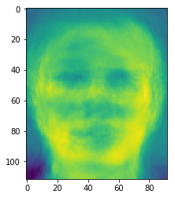

```python
eigvalues=pca1.components_
a1=skl_pca1.dot(eigvalues)
a1.shape
plt.imshow(np.array(a1[0],dtype=float).reshape((112,92),order="F"))
```

#### ACP k=10

**Avec `fit_transform` :**

```python
approximation2=pca2.inverse_transform(skl_pca2) #redimensionner les données à la représentation d'origine
def visage_acp10():
    plt.imshow(np.array(approximation2[0],dtype=float).reshape((112,92),order="F"))
```

**Avec la matrice des vecteurs propres :**

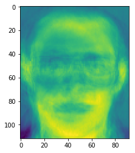

```python
eigvalues=pca2.components_
a2=skl_pca2.dot(eigvalues)
a2.shape
plt.imshow(np.array(a2[0],dtype=float).reshape((112,92),order="F"))
```

#### ACP k=50

**Avec `fit_transform` :**

```python
approximation3=pca3.inverse_transform(skl_pca3) #redimensionner les données à la représentation d'origine
def visage_acp50():
    plt.imshow(np.array(approximation3[0],dtype=float).reshape((112,92),order="F"))
```

**Avec la matrice des vecteurs propres :**

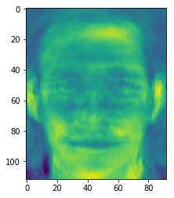

```python
eigvalues=pca3.components_
a3=skl_pca3.dot(eigvalues)
a3.shape
plt.imshow(np.array(a3[0],dtype=float).reshape((112,92),order="F"))
```

#### Vrai visage

```python
def vrai_visage():
    plt.imshow(np.array(TrainI.T[0],dtype=float).reshape((112,92),order="F"))
```

Retour à la question 3

### Code 5

```python
pca_test=PCA(n_components=5)
skl_pca_test=pca_test.fit_transform(TestI)
```

```python
from math import sqrt #pour le sqrt de la fonction distanceEu
def distanceEu(a,b): #fonction qui calcul la distance euclidienne entre 2 éléments (a,b) ici des images
    somme = 0
    for i in range(len(a)): #pour i parcourant tte les coordonnées de a (en l'occurence, les pixels d'une image)
        somme=somme+(a[i]-b[i])*(a[i]-b[i]) # on calcul le carré de la différence entre le pixel a et le b
    return(sqrt(somme)) #une fois la somme des carrés de toutes les différences de pixels entre a et b calculé,
                        #on en fait la racine carré pour obtenir la distance euclidienne

def lesKppv(t,k):
    listeDist = [] #liste contenant les distances euclidiennes entre t(qui sera une image de TestI) et chaque image de TrainI
    for i in range(0,len(skl_pca1)): #pour i parcourant tte les images (ligne) de TrainI réduit par ACP (skl_pca1)
        listeDist.append(distanceEu(t, np.array(skl_pca1)[i][:])) #on calcul la distance entre t et l'image i
    listeKppv = [] #liste contenant les indice de image faisance parti de k plus proche voisins de t
    for i in range(k):
        p = np.inf #on prend p infini car dans un premier temps ts le monde peut être plus proche voisin
                   #Il agit comme une valeur supérieure non bornée pour la comparaison.
                   #Ceci est utile pour trouver les valeurs les plus basses pour quelque chose.
                   #équivalent à float(inf) et math.inf
        for j in range(0,len(skl_pca_test)):
            if listeDist[j]!=0 and listeDist[j]<p and j not in listeKppv:
            #si la distance j est différent de 0, plus petit que p et pas déjà présente dans la liste
                p=listeDist[j] #p devient la distance la plus petite
                indice=j #on retient l'indice de cette distance
        listeKppv.append(indice) #on ajoute la distance sélectionné par le for dans la liste des kppv et on chercherla suivante
    return(listeKppv) #on retourne la liste d'indice final une fois ts les kppv trouvé

def prediction (l):
    labels = [i for i in range(1,41)] #on crée une liste [1,2,3,4,...,40] représentant les labels
    compteur = np.zeros(40) #on crée un array contenant 40 zeros, il compte dans la liste l (contenant les indices des kppv)
                            #le nombre d'apparition d'un certain label
    for voisin in l : #pour voisin parcourant la liste l
        for i in range(0,40): #pour i parcourant les différentes modalités de labels
            if np.array(TrainL)[0,voisin] == labels[i]: #si le labels du plus proche voisin correpond à la modalité de label i
                compteur[i] += 1 #alors le compteur augmente d'une unité
    max_nb_labels = 0 #servira de comparateur entre ts les compteurs obtenu précédemment
    indice = 0 #l'indice du plus grand compteur retenu à chaque itération
    for i in range(0,40): #pour parcourant ts les compteurs
        if compteur[i] > max_nb_labels: #si le compteur i est plus que le maximum de compteur
            max_nb_labels = compteur[i] #alors le maximum des compteurs devient le compteur i
            indice = i #et on retient l'indice du compteur pour cette itération
    #à la fin de la boucle for on obtient l'indice du qui dans la liste de labels correspondra au labels prédit
    #pour l'élément dont on a pris en paramètre ses kppv
    return (labels[indice]) #on retourne ce label

def afficheLabel(n,k): #n est nombre de visage dont on veut afficher le label n=80 si on veut tous les afficher
    for i in range(n): #pour i parcourant toutes les images de TestI
        print("Visage "+ str(i+1)+ " : ")
        print("Label prédit :"+ str(prediction(lesKppv(np.array(skl_pca_test)[i][:],k)))
              + " | Vrai label : "+ str(np.array(TestL)[0][i]))
```

Retour à la question 5

### Code 6

#### Analyse d'erreurs sur les labels prédit

```python
def analyseErreurs(k):
    nombreErreurs = 0 #le nombre d'erreurs est initialisé à 0
    for i in range(80): #pour i parcourant toutes les images de TestI
        if prediction(lesKppv(np.array(skl_pca_test)[i][:],k))!=np.array(TestL)[0][i]:
        #si le label prédit par la fonction prédiction est différents du vrai label
            nombreErreurs+= 1 #alors le nombre d'erreurs augmente d'une unité
    #on affiche la proportion d'erreurs sur les labels prédit
    print("Proportion d'erreurs pour k = " + str(k) + " : " + str(float(nombreErreurs)/len(skl_pca_test)))
```

Retour à la question 6

### Code 7

```python
def lesKppv2(t,k):
    listeDist = []
    for i in range(0,len(TrainI)): #pour i parcourant tte les images (ligne) de TrainI
        listeDist.append(distanceEu(t, np.array(TrainI)[i][:])) #on calcul cette fois la distance avec le dataset original
    listeKppv = []
    for i in range(k):
        p = np.inf
        for j in range(0,len(TrainI)):
            if listeDist[j]!=0 and listeDist[j]<p and j not in listeKppv:
                p=listeDist[j]
                indice=j
        listeKppv.append(indice)
    return(listeKppv)

def afficheLabel2(n,k):
    for i in range(n):
        print("Visage "+ str(i+1)+ " : ")
        print("Label prédit :"+ str(prediction(lesKppv2(np.array(TestI)[i][:],k)))
              + " | Vrai label : "+ str(np.array(TestL)[0][i]))
```

```python
def analyseErreurs2(k):
    nombreErreurs = 0
    for i in range(80):
        if prediction(lesKppv2(np.array(TestI)[i][:],k))!=np.array(TestL)[0][i]: #avec cette fois TestI
        #si le label prédit par la fonction prédiction est différents du vrai label
            nombreErreurs+= 1
    print("Proportion d'erreurs pour k = " + str(k) + " : " + str(float(nombreErreurs)/len(TestI)))
```

Retour à la question 7

#### Recherche du paramètres k optimal

```python
from sklearn import model_selection
from sklearn import neighbors, metrics
```

```python
def gridSearch():
    param={'n_neighbors':[3,5,10,15,20,30,40,50]} #on fixe les valeurs des hyperparamètres à tester
    score='accuracy'
    #recherche sur la base d'un k plus proche voisin les hyperparamètres par la méthode de la validation croisée
    testParam = model_selection.GridSearchCV(neighbors.KNeighborsClassifier(),
    param, # hyperparamètres à tester
    cv=6, # nombre de folds de validation croisée avec la méthode stratifié
    scoring=score #on choisi le score "accuracy" à optimiser, il représente la proportion de prédictions correctes
    )

    testParam.fit(TrainI, np.array(TrainL).ravel()) #on applique cette recherche sur TrainI avec ses labels dans TrainL
    #ravel car sinon on nous affiche un message d'erreur nous demandant que le tableau doit être 1-D

    #Pour afficher les résultat de chaque test
    print("Résultats de la validation croisée :")
    for mean, params in zip(testParam.cv_results_['mean_test_score'], # score moyen
    testParam.cv_results_['params'] # valeur de l'hyperparamètre
    ):
        print(str(score) + " = " + str(mean) +  " pour k = " + str(params))
    #Pour afficher le meilleur résultat
    print("Meilleur hyperparamètre :" + str(testParam.best_params_)) #on affiche l'hyperparamètre optimal parmi la liste testé

    #On applique finalement le k plus proche voisin avec l'hyperparamètre trouvé sur le dataset TestI
    y_pred = testParam.predict(TestI)
    print("Proportion de prédiction correct sur TestI : " + str(metrics.accuracy_score(np.array(TestL).ravel(), y_pred)))
```

Retour à la question 7

# Exercice 2

### Code : Chargement du dataset

```python
df=pd.read_csv("zomato.csv",encoding = "ISO-8859-1")
```

Retour à l'exercice

### Code : Nettoyage et optimisation des données

#### Code : Gestion des valeurs manquantes

```python
df.isna().sum() #nombre de valeurs manquantes dans chaque variable
```

```
Restaurant ID           0
Restaurant Name         0
Country Code            0
City                    0
Address                 0
Locality                0
Locality Verbose        0
Longitude               0
Latitude                0
Cuisines                9
Average Cost for two    0
Currency                0
Has Table booking       0
Has Online delivery     0
Is delivering now       0
Switch to order menu    0
Price range             0
Aggregate rating        0
Rating color            0
Rating text             0
Votes                   0
dtype: int64
```

Retour à l'exercice

#### Code : Décodage de la variable Country Code

```python
import folium
```

```python
CodeCountry=df["Country Code"].unique() #les différentes modalités (code) prisent par la variable "Country Code"
indexCountry=[] #liste pour regrouper des sous listes d'indices des restaurants par pays
for j in CodeCountry:
    indexCountry.append([i for i in range(0,len(df)) if df["Country Code"][i]==j])
```

```python
monde = folium.Map([0,0],zoom_start=2)
for i in range(0,15): #15 car il y a 15 pays en tout
    coordonne=[df["Latitude"][indexCountry[i][0]],df["Longitude"][indexCountry[i][0]]]
    #coordonnées tirées du dataframe et représentant le 1er restaurant de la sous liste i (donc 1er restaurant du pays i)
    folium.Marker(coordonne,popup=str(CodeCountry[i])).add_to(monde)
```

```python
#Ce dataframe ne sert qu'à afficher un tableau ordonnée des correspondance entre code et nom
Country_Code_Name=pd.DataFrame({"Country Code" : CodeCountry,
                                "Country Name" : ["Philippines", "Brésil", "USA", "Australie","Canada", "Singapour", "EAU",
                                                  "Inde","Indonésie","Nouvelle Zelande","RU", "Qatar", "Afrique du Sud",
                                                  "Sri Lanka", "Turquie"]})
```

```python
#ajout de la variable Country Name dans la copie du dataframe, cette variable contient le nom des pays selon leur code
df2=df.copy()
df2["Country Name"]=df2["Country Code"]
for i in range(0,15):
    df2["Country Name"]=df2["Country Name"].replace(Country_Code_Name["Country Code"][i],Country_Code_Name["Country Name"][i])
```

Retour à l'exercice

#### Code : Conversion des prix moyen en dollars américain

```python
#permet d'avoir la devise pour chaque pays : ici utiliser unique() ne fonctionnerai pas car plusieurs pays utilise le dollars
#on utilise donc indexCountry qui est une liste de sous listes
#dont chaque sous liste correpond à un pays et contient les indices des restaurants du pays
#donc en prenant l'indice du 1er restaurant de chaque sous liste correpondant à un pays on aura la devise correspondante
currency_country=[]
for i in range(0,15) :
    currency_country.append(df["Currency"][indexCountry[i][0]])
```

```python
#dataframe pour afficher le tableau des devise et leur taux de change
ConvertCurrency=pd.DataFrame({"Currency":currency_country, #on ne peut pas mettre df["Currency"].unique() car plusieurs fois dollars
                        "To Convert dollars":[0.019,0.25,1,0.72,0.75,0.74,0.27,0.014,0.000071,0.67,1.30,0.27,0.071,0.0057,0.17]})
```

```python
#ajout de la variable Convert_dollars qui correspond au taux de change
df2["Convert_dollars"]=df2["Currency"]
for i in range(0,15):
    df2["Convert_dollars"]=df2["Convert_dollars"].replace(ConvertCurrency["Currency"][i],ConvertCurrency["To Convert dollars"][i])
```

```python
#converti chaque prix moyen pour deux personnes en dollars grâce au taux de change
#puis ajout de la variable dans le dataframe
AverageCostDollars=[]
for i,k in zip(range(0,15),ConvertCurrency["To Convert dollars"]):
    for j in indexCountry[i]:
        AverageCostDollars.append(k * df['Average Cost for two'][j])
df2["Average Cost in dollars"]=AverageCostDollars
```

Retour à l'exercice

#### Code : Création de catégories de prix

```python
#création de 4 catégories de prix
df2["cat_cost"]=df2["Average Cost in dollars"].apply(
    lambda x : "[0,30]" if x<30 else "[30,60]" if x <60 else "[60,100]" if x <100 else "[100,+]")
df2
```

|  | Restaurant ID | Restaurant Name | Country Code | City | Address | Locality | Locality Verbose | Longitude | Latitude | Cuisines | ... | Switch to order menu | Price range | Aggregate rating | Rating color | Rating text | Votes | Country Name | Convert_dollars | Average Cost in dollars | cat_cost |
| --- | --- | --- | --- | --- | --- | --- | --- | --- | --- | --- | --- | --- | --- | --- | --- | --- | --- | --- | --- | --- | --- |
| 0 | 6317637 | Le Petit Souffle | 162 | Makati City | Third Floor, Century City Mall, Kalayaan Avenu... | Century City Mall, Poblacion, Makati City | Century City Mall, Poblacion, Makati City, Mak... | 121.027535 | 14.565443 | French, Japanese, Desserts | ... | No | 3 | 4.8 | Dark Green | Excellent | 314 | Philippines | 0.019 | 20.90 | [0,30] |
| 1 | 6304287 | Izakaya Kikufuji | 162 | Makati City | Little Tokyo, 2277 Chino Roces Avenue, Legaspi... | Little Tokyo, Legaspi Village, Makati City | Little Tokyo, Legaspi Village, Makati City, Ma... | 121.014101 | 14.553708 | Japanese | ... | No | 3 | 4.5 | Dark Green | Excellent | 591 | Philippines | 0.019 | 22.80 | [0,30] |
| 2 | 6300002 | Heat - Edsa Shangri-La | 162 | Mandaluyong City | Edsa Shangri-La, 1 Garden Way, Ortigas, Mandal... | Edsa Shangri-La, Ortigas, Mandaluyong City | Edsa Shangri-La, Ortigas, Mandaluyong City, Ma... | 121.056831 | 14.581404 | Seafood, Asian, Filipino, Indian | ... | No | 4 | 4.4 | Green | Very Good | 270 | Philippines | 0.019 | 76.00 | [60,100] |
| 3 | 6318506 | Ooma | 162 | Mandaluyong City | Third Floor, Mega Fashion Hall, SM Megamall, O... | SM Megamall, Ortigas, Mandaluyong City | SM Megamall, Ortigas, Mandaluyong City, Mandal... | 121.056475 | 14.585318 | Japanese, Sushi | ... | No | 4 | 4.9 | Dark Green | Excellent | 365 | Philippines | 0.019 | 28.50 | [0,30] |
| 4 | 6314302 | Sambo Kojin | 162 | Mandaluyong City | Third Floor, Mega Atrium, SM Megamall, Ortigas... | SM Megamall, Ortigas, Mandaluyong City | SM Megamall, Ortigas, Mandaluyong City, Mandal... | 121.057508 | 14.584450 | Japanese, Korean | ... | No | 4 | 4.8 | Dark Green | Excellent | 229 | Philippines | 0.019 | 28.50 | [0,30] |
| 5 | 18189371 | Din Tai Fung | 162 | Mandaluyong City | Ground Floor, Mega Fashion Hall, SM Megamall, ... | SM Megamall, Ortigas, Mandaluyong City | SM Megamall, Ortigas, Mandaluyong City, Mandal... | 121.056314 | 14.583764 | Chinese | ... | No | 3 | 4.4 | Green | Very Good | 336 | Philippines | 0.019 | 19.00 | [0,30] |
| 6 | 6300781 | Buffet 101 | 162 | Pasay City | Building K, SM By The Bay, Sunset Boulevard, M... | SM by the Bay, Mall of Asia Complex, Pasay City | SM by the Bay, Mall of Asia Complex, Pasay Cit... | 120.979667 | 14.531333 | Asian, European | ... | No | 4 | 4.0 | Green | Very Good | 520 | Philippines | 0.019 | 38.00 | [30,60] |
| 7 | 6301290 | Vikings | 162 | Pasay City | Building B, By The Bay, Seaside Boulevard, Mal... | SM by the Bay, Mall of Asia Complex, Pasay City | SM by the Bay, Mall of Asia Complex, Pasay Cit... | 120.979333 | 14.540000 | Seafood, Filipino, Asian, European | ... | No | 4 | 4.2 | Green | Very Good | 677 | Philippines | 0.019 | 38.00 | [30,60] |
| 8 | 6300010 | Spiral - Sofitel Philippine Plaza Manila | 162 | Pasay City | Plaza Level, Sofitel Philippine Plaza Manila, ... | Sofitel Philippine Plaza Manila, Pasay City | Sofitel Philippine Plaza Manila, Pasay City, P... | 120.980090 | 14.552990 | European, Asian, Indian | ... | No | 4 | 4.9 | Dark Green | Excellent | 621 | Philippines | 0.019 | 114.00 | [100,+] |
| 9 | 6314987 | Locavore | 162 | Pasig City | Brixton Technology Center, 10 Brixton Street, ... | Kapitolyo | Kapitolyo, Pasig City | 121.056532 | 14.572041 | Filipino | ... | No | 3 | 4.8 | Dark Green | Excellent | 532 | Philippines | 0.019 | 20.90 | [0,30] |
| 10 | 6309903 | Silantro Fil-Mex | 162 | Pasig City | 75 East Capitol Drive, Kapitolyo, Pasig City | Kapitolyo | Kapitolyo, Pasig City | 121.057916 | 14.567689 | Filipino, Mexican | ... | No | 3 | 4.9 | Dark Green | Excellent | 1070 | Philippines | 0.019 | 15.20 | [0,30] |
| 11 | 6309455 | Mad Mark's Creamery & Good Eats | 162 | Pasig City | 23 East Capitol Drive, Kapitolyo, Pasig City | Kapitolyo | Kapitolyo, Pasig City | 121.060820 | 14.570849 | American, Ice Cream, Desserts | ... | No | 3 | 4.2 | Green | Very Good | 488 | Philippines | 0.019 | 17.10 | [0,30] |
| 12 | 6318433 | Silantro Fil-Mex | 162 | Quezon City | Second Floor, UP Town Center, Katipunan Avenue... | UP Town Center, Diliman, Quezon City | UP Town Center, Diliman, Quezon City, Quezon City | 121.075419 | 14.649503 | Filipino, Mexican | ... | No | 3 | 4.8 | Dark Green | Excellent | 294 | Philippines | 0.019 | 15.20 | [0,30] |
| 13 | 6310470 | Guevarra's | 162 | San Juan City | 387 P. Guevarra Corner Argonne Street, Additio... | Addition Hills | Addition Hills, San Juan City | 121.033592 | 14.593450 | Filipino | ... | No | 3 | 4.2 | Green | Very Good | 458 | Philippines | 0.019 | 19.00 | [0,30] |
| 14 | 6314605 | Sodam Korean Restaurant | 162 | San Juan City | 17 J. Abad Santos Drive, Little Baguio, San Ju... | Little Baguio | Little Baguio, San Juan City | 121.038110 | 14.598890 | Korean | ... | No | 3 | 4.3 | Green | Very Good | 223 | Philippines | 0.019 | 13.30 | [0,30] |
| 15 | 18185059 | Cafe Arabelle | 162 | Santa Rosa | Ayala Mall, Solenad, Nuvali, Santa Rosa - Taga... | Nuvali, Don Jose, Santa Rosa | Nuvali, Don Jose, Santa Rosa, Santa Rosa | 121.057040 | 14.237082 | Cafe, American, Italian, Filipino | ... | No | 3 | 3.6 | Yellow | Good | 29 | Philippines | 0.019 | 15.20 | [0,30] |
| 16 | 18182702 | Nonna's Pasta & Pizzeria | 162 | Santa Rosa | Ground Floor, Building G, Solenad 3, Nuvali, D... | Solenad 3, Don Jose, Santa Rosa | Solenad 3, Don Jose, Santa Rosa, Santa Rosa | 121.056587 | 14.237679 | Italian, Pizza | ... | No | 3 | 4.0 | Green | Very Good | 72 | Philippines | 0.019 | 16.15 | [0,30] |
| 17 | 6318213 | Balay Dako | 162 | Tagaytay City | Aguinaldo Highway, Tagaytay City | Tagaytay City | Tagaytay City, Tagaytay City | 120.951589 | 14.101834 | Filipino | ... | No | 3 | 4.5 | Dark Green | Excellent | 211 | Philippines | 0.019 | 22.80 | [0,30] |
| 18 | 18255654 | Hobing Korean Dessert Cafe | 162 | Taguig City | Third Floor, BGC Stopover Pavillion, Rizal Dri... | BGC Stopover Pavillion, Bonifacio Global City | BGC Stopover Pavillion, Bonifacio Global City,... | 121.045878 | 14.554360 | Cafe, Korean, Desserts | ... | No | 2 | 4.5 | Dark Green | Excellent | 118 | Philippines | 0.019 | 11.40 | [0,30] |
| 19 | 6308205 | Wildflour Cafe + Bakery | 162 | Taguig City | Ground Floor, Netlima Building, 4th Avenue Cor... | Bonifacio Global City | Bonifacio Global City, Taguig City | 121.046220 | 14.549337 | Cafe, Bakery, American, Italian | ... | No | 4 | 4.4 | Green | Very Good | 392 | Philippines | 0.019 | 28.50 | [0,30] |
| 20 | 6315438 | NIU by Vikings | 162 | Taguig City | Sixth Floor, SM Aura Premier, C5 Road Corner 2... | SM Aura Premier, Bonifacio Global City, Taguig... | SM Aura Premier, Bonifacio Global City, Taguig... | 121.053725 | 14.545858 | Seafood, American, Mediterranean, Japanese | ... | No | 4 | 4.7 | Dark Green | Excellent | 535 | Philippines | 0.019 | 57.00 | [30,60] |
| 21 | 6310406 | The Food Hall by Todd English | 162 | Taguig City | Fifth Floor, SM Aura Premier, C5 Corner 26th S... | SM Aura Premier, Bonifacio Global City, Taguig... | SM Aura Premier, Bonifacio Global City, Taguig... | 121.053500 | 14.545655 | American, Asian, Italian, Seafood | ... | No | 4 | 4.5 | Dark Green | Excellent | 618 | Philippines | 0.019 | 34.20 | [30,60] |
| 22 | 6600681 | Chez Michou | 30 | Brasí_lia | SCLN, 208, Bloco A, Loja 30, Asa Norte, Brasí_lia | Asa Norte | Asa Norte, Brasí_lia | -47.881789 | -15.764142 | Fast Food, French | ... | No | 2 | 3.0 | Orange | Average | 6 | Brésil | 0.250 | 13.75 | [0,30] |
| 23 | 6601005 | Cafí© Daniel Briand | 30 | Brasí_lia | SCLN 104, Bloco A, Loja 26, Asa Norte, Brasí_lia | Asa Norte | Asa Norte, Brasí_lia | -47.882667 | -15.777500 | Cafe | ... | No | 1 | 3.8 | Yellow | Good | 9 | Brésil | 0.250 | 7.50 | [0,30] |
| 24 | 6600292 | Casa do Biscoito Mineiro | 30 | Brasí_lia | SCLN 210, Bloco D, Loja 36/48, Asa Norte, Bras... | Asa Norte | Asa Norte, Brasí_lia | -47.882136 | -15.757472 | Bakery | ... | No | 2 | 3.7 | Yellow | Good | 11 | Brésil | 0.250 | 11.25 | [0,30] |
| 25 | 6600441 | Maori | 30 | Brasí_lia | CLN 110, Bloco D, Loja 28, Asa Norte, Brasí_lia | Asa Norte | Asa Norte, Brasí_lia | -47.888167 | -15.758833 | Brazilian | ... | No | 3 | 3.8 | Yellow | Good | 11 | Brésil | 0.250 | 15.00 | [0,30] |
| 26 | 6600970 | Pizza íæ Bessa | 30 | Brasí_lia | SCS 214, Bloco C, Loja 40, Asa Sul, Brasí_lia | Asa Sul | Asa Sul, Brasí_lia | -47.915667 | -15.831167 | Pizza | ... | No | 2 | 3.2 | Orange | Average | 11 | Brésil | 0.250 | 12.50 | [0,30] |
| 27 | 6600379 | Sushi Loko | 30 | Brasí_lia | SCS 213, Bloco C, Loja 35, Asa Sul, Brasí_lia | Asa Sul | Asa Sul, Brasí_lia | -47.915667 | -15.831000 | Japanese | ... | No | 3 | 3.1 | Orange | Average | 10 | Brésil | 0.250 | 20.00 | [0,30] |
| 28 | 6600214 | Beirute | 30 | Brasí_lia | CLS 109, Bloco A, Loja 2/6, Asa Sul, Brasí_lia | Asa Sul | Asa Sul, Brasí_lia | -47.907500 | -15.820000 | Arabian | ... | No | 3 | 3.7 | Yellow | Good | 8 | Brésil | 0.250 | 22.50 | [0,30] |
| 29 | 6601218 | New Koto | 30 | Brasí_lia | SCS 212, Bloco B, Loja 26, Asa Sul, Brasí_lia | Asa Sul | Asa Sul, Brasí_lia | -47.910167 | -15.827333 | Japanese | ... | No | 4 | 3.7 | Yellow | Good | 5 | Brésil | 0.250 | 50.00 | [30,60] |
| ... | ... | ... | ... | ... | ... | ... | ... | ... | ... | ... | ... | ... | ... | ... | ... | ... | ... | ... | ... | ... | ... |
| 9521 | 6003426 | Liva | 208 | Ankara | íukurambar Mahallesi, Muhsin YazÛ±cÛ±oÛôlu Ca... | íukurambar | íukurambar, Ankara | 32.809146 | 39.904709 | Patisserie, Coffee and Tea | ... | No | 2 | 3.4 | Orange | Average | 115 | Turquie | 0.170 | 8.50 | [0,30] |
| 9522 | 6000549 | Meôhur TavacÛ± Recep Usta | 208 | Ankara | Gí_zeltepe Mahallesi, Dikmen Vadisi, Hoôdere ... | Dikmen | Dikmen, Ankara | 32.846189 | 39.884872 | Kebab | ... | No | 3 | 4.5 | Dark Green | Excellent | 231 | Turquie | 0.170 | 17.00 | [0,30] |
| 9523 | 6000871 | íukuraÛôa SofrasÛ± | 208 | Ankara | Emek Mahallesi, Bosna Hersek Caddesi, No 22/C,... | Emek | Emek, Ankara | 32.818833 | 39.916667 | Kebab, Izgara | ... | No | 3 | 4.4 | Green | Very Good | 296 | Turquie | 0.170 | 10.20 | [0,30] |
| 9524 | 6004011 | Gaga Manjero | 208 | Ankara | Gazi Osman Paôa Mahallesi, Filistin Caddesi, ... | Gazi Osman Paôa | Gazi Osman Paôa, Ankara | 32.869800 | 39.898239 | World Cuisine | ... | No | 3 | 4.9 | Dark Green | Excellent | 95 | Turquie | 0.170 | 13.60 | [0,30] |
| 9525 | 6000409 | Cafemiz | 208 | Ankara | Gaziosmanpaôa Mahallesi, Arjantin Caddesi, No... | Gazi Osman Paôa | Gazi Osman Paôa, Ankara | 32.865683 | 39.897872 | World Cuisine, Mexican, Italian | ... | No | 4 | 4.4 | Green | Very Good | 115 | Turquie | 0.170 | 25.50 | [0,30] |
| 9526 | 6000019 | Nusr-Et | 208 | Ankara | Gaziosmanpaôa Mahallesi, _ehit í_mer Haluk S... | Gazi Osman Paôa | Gazi Osman Paôa, Ankara | 32.864833 | 39.899667 | Steak | ... | No | 4 | 4.1 | Green | Very Good | 97 | Turquie | 0.170 | 68.00 | [60,100] |
| 9527 | 6001537 | Kebap 49 | 208 | Ankara | Remzi OÛôuz ArÛ±k Mahallesi, TunalÛ± Hilmi Cad... | KavaklÛ±dere | KavaklÛ±dere, Ankara | 32.860144 | 39.907272 | Kebab, Turkish Pizza | ... | No | 3 | 4.3 | Green | Very Good | 106 | Turquie | 0.170 | 10.20 | [0,30] |
| 9528 | 6003668 | Timboo Cafe | 208 | Ankara | Kentpark AVM, Kat -1, Mustafa Kemal Mahallesi,... | Kentpark AVM, íìniversiteler, íankaya | Kentpark AVM, íìniversiteler, íankaya, Ankara | 32.776255 | 39.908957 | Cafe | ... | No | 3 | 4.2 | Green | Very Good | 79 | Turquie | 0.170 | 11.90 | [0,30] |
| 9529 | 6001748 | Meôhur í_zí_elik Aspava | 208 | Ankara | Kí_í_í_k Esat Mahallesi, Esat Caddesi, No 110/... | Kí_í_í_k Esat | Kí_í_í_k Esat, Ankara | 32.866633 | 39.906636 | Kebab, Turkish Pizza | ... | No | 2 | 4.6 | Dark Green | Excellent | 109 | Turquie | 0.170 | 6.80 | [0,30] |
| 9530 | 6001757 | YÛ±ldÛ±z Aspava | 208 | Ankara | Kí_í_í_k Esat Mahallesi, Esat Caddesi, No 110/... | Kí_í_í_k Esat | Kí_í_í_k Esat, Ankara | 32.866608 | 39.906569 | Kebab, Turkish Pizza, Dí_ner | ... | No | 2 | 4.4 | Green | Very Good | 72 | Turquie | 0.170 | 8.50 | [0,30] |
| 9531 | 6000747 | The Bigos | 208 | Ankara | Mahallesi, Selanik 2 Caddesi, No 61/A, íankay... | KÛ±zÛ±lay | KÛ±zÛ±lay, Ankara | 32.857917 | 39.916686 | Cafe | ... | No | 3 | 3.8 | Yellow | Good | 123 | Turquie | 0.170 | 13.60 | [0,30] |
| 9532 | 6002025 | MasabaôÛ± | 208 | Ankara | Kocatepe Mahallesi, Mithatpaôa Caddesi, No 62... | KÛ±zÛ±lay | KÛ±zÛ±lay, Ankara | 32.859867 | 39.919144 | Kebab, Turkish Pizza | ... | No | 3 | 4.2 | Green | Very Good | 103 | Turquie | 0.170 | 17.00 | [0,30] |
| 9533 | 6003879 | Zigana Pide | 208 | Ankara | Macun Mahallesi, Erciyes ÛÁôyerleri Sitesi, 2... | Macunkí_y | Macunkí_y, Ankara | 32.763378 | 39.946278 | Turkish Pizza | ... | No | 2 | 4.3 | Green | Very Good | 103 | Turquie | 0.170 | 8.50 | [0,30] |
| 9534 | 6004089 | Dí_veroÛôlu | 208 | Ankara | Maltepe Mahallesi, Gení_lik Caddesi, No 28, í... | Maltepe | Maltepe, Ankara | 32.842742 | 39.922536 | Kebab, Desserts, Turkish Pizza | ... | No | 3 | 4.4 | Green | Very Good | 131 | Turquie | 0.170 | 11.90 | [0,30] |
| 9535 | 6000921 | Dí_veroÛôlu | 208 | Ankara | íìmitkí_y Mahallesi, 2432. Cadde (8. Cadde), N... | íìmitkí_y | íìmitkí_y, Ankara | 32.701775 | 39.891564 | Kebab, Desserts, Turkish Pizza | ... | No | 3 | 4.2 | Green | Very Good | 152 | Turquie | 0.170 | 11.90 | [0,30] |
| 9536 | 6004813 | Pizza ÛÁl Forno | 208 | Ankara | YÛ±ldÛ±zevler Mahallesi, 720. Sokak, No 2/B, í... | YÛ±ldÛ±zevler | YÛ±ldÛ±zevler, Ankara | 32.860217 | 39.876239 | Pizza | ... | No | 2 | 4.7 | Dark Green | Excellent | 104 | Turquie | 0.170 | 6.80 | [0,30] |
| 9537 | 5904116 | J'adore Chocolatier | 208 | ÛÁstanbul | AsmalÛ±mescit Mahallesi, ÛÁstiklal Caddesi, Em... | AsmalÛ±mescit | AsmalÛ±mescit, ÛÁstanbul | 28.976127 | 41.033002 | Desserts | ... | No | 2 | 4.7 | Dark Green | Excellent | 1311 | Turquie | 0.170 | 8.50 | [0,30] |
| 9538 | 5901782 | Starbucks | 208 | ÛÁstanbul | Bebek Mahallesi, Cevdetpaôa Caddesi, No 30/A,... | Bebek | Bebek, ÛÁstanbul | 29.043734 | 41.077696 | Cafe | ... | No | 2 | 4.9 | Dark Green | Excellent | 1042 | Turquie | 0.170 | 5.10 | [0,30] |
| 9539 | 5902117 | Valonia | 208 | ÛÁstanbul | Tí_rkali Mahallesi, Ihlamurdere Caddesi, No 40... | Beôiktaô Merkez | Beôiktaô Merkez, ÛÁstanbul | 29.002896 | 41.044813 | Restaurant Cafe, Desserts | ... | No | 3 | 4.2 | Green | Very Good | 874 | Turquie | 0.170 | 13.60 | [0,30] |
| 9540 | 5927248 | Draft Gastro Pub | 208 | ÛÁstanbul | Caddebostan Mahallesi, BaÛôdat Caddesi, No 349... | Caddebostan | Caddebostan, ÛÁstanbul | 29.074116 | 40.963935 | Bar Food | ... | No | 4 | 4.9 | Dark Green | Excellent | 522 | Turquie | 0.170 | 22.10 | [0,30] |
| 9541 | 5905215 | Emirgan Sí_tiô | 208 | ÛÁstanbul | Emirgan Mahallesi, SakÛ±p SabancÛ± Caddesi, No... | Emirgí¢n | Emirgí¢n, ÛÁstanbul | 29.056620 | 41.104969 | Restaurant Cafe, Turkish, Desserts | ... | No | 3 | 4.2 | Green | Very Good | 877 | Turquie | 0.170 | 12.75 | [0,30] |
| 9542 | 5926979 | Leman Kí_ltí_r | 208 | ÛÁstanbul | CaferaÛôa Mahallesi, Neôet í_mer Sokak, No 9/... | KadÛ±kí_y Merkez | KadÛ±kí_y Merkez, ÛÁstanbul | 29.022805 | 40.989705 | Restaurant Cafe | ... | No | 3 | 3.7 | Yellow | Good | 506 | Turquie | 0.170 | 13.60 | [0,30] |
| 9543 | 5916085 | Dem Karakí_y | 208 | ÛÁstanbul | Kemankeô Karamustafa Paôa Mahallesi, Hoca Ta... | Karakí_y | Karakí_y, ÛÁstanbul | 28.978236 | 41.024633 | Cafe | ... | No | 2 | 4.5 | Dark Green | Excellent | 761 | Turquie | 0.170 | 5.95 | [0,30] |
| 9544 | 5915547 | Karakí_y Gí_llí_oÛôlu | 208 | ÛÁstanbul | Kemankeô Karamustafa Paôa Mahallesi, RÛ±htÛ±... | Karakí_y | Karakí_y, ÛÁstanbul | 28.977636 | 41.022904 | Desserts, Bí_rek | ... | No | 2 | 4.7 | Dark Green | Excellent | 1305 | Turquie | 0.170 | 6.80 | [0,30] |
| 9545 | 5915054 | Baltazar | 208 | ÛÁstanbul | Kemankeô Karamustafa Paôa Mahallesi, KÛ±lÛ±í... | Karakí_y | Karakí_y, ÛÁstanbul | 28.981103 | 41.025785 | Burger, Izgara | ... | No | 3 | 4.3 | Green | Very Good | 870 | Turquie | 0.170 | 15.30 | [0,30] |
| 9546 | 5915730 | NamlÛ± Gurme | 208 | ÛÁstanbul | Kemankeô Karamustafa Paôa Mahallesi, RÛ±htÛ±... | Karakí_y | Karakí_y, ÛÁstanbul | 28.977392 | 41.022793 | Turkish | ... | No | 3 | 4.1 | Green | Very Good | 788 | Turquie | 0.170 | 13.60 | [0,30] |
| 9547 | 5908749 | Ceviz AÛôacÛ± | 208 | ÛÁstanbul | Koôuyolu Mahallesi, Muhittin íìstí_ndaÛô Cadd... | Koôuyolu | Koôuyolu, ÛÁstanbul | 29.041297 | 41.009847 | World Cuisine, Patisserie, Cafe | ... | No | 3 | 4.2 | Green | Very Good | 1034 | Turquie | 0.170 | 17.85 | [0,30] |
| 9548 | 5915807 | Huqqa | 208 | ÛÁstanbul | Kuruí_eôme Mahallesi, Muallim Naci Caddesi, N... | Kuruí_eôme | Kuruí_eôme, ÛÁstanbul | 29.034640 | 41.055817 | Italian, World Cuisine | ... | No | 4 | 3.7 | Yellow | Good | 661 | Turquie | 0.170 | 28.90 | [0,30] |
| 9549 | 5916112 | Aôôk Kahve | 208 | ÛÁstanbul | Kuruí_eôme Mahallesi, Muallim Naci Caddesi, N... | Kuruí_eôme | Kuruí_eôme, ÛÁstanbul | 29.036019 | 41.057979 | Restaurant Cafe | ... | No | 4 | 4.0 | Green | Very Good | 901 | Turquie | 0.170 | 20.40 | [0,30] |
| 9550 | 5927402 | Walter's Coffee Roastery | 208 | ÛÁstanbul | CafeaÛôa Mahallesi, BademaltÛ± Sokak, No 21/B,... | Moda | Moda, ÛÁstanbul | 29.026016 | 40.984776 | Cafe | ... | No | 2 | 4.0 | Green | Very Good | 591 | Turquie | 0.170 | 9.35 | [0,30] |

9551 rows × 25 columns

Retour à l'exercice

### Code : Analyse exploratoire des données

```python
import seaborn
```

```python
def boxplot1():
    seaborn.factorplot(x = "Country Name", y = "Average Cost in dollars", data = df2, kind = "box",size=15)
```

```python
def boxplot2():
    seaborn.factorplot(x = "Country Name", y = "Aggregate rating", data = df2, kind = "box",size=15)
```

```python
def histo1():
    INDE=df2.iloc[indexCountry[7]] #l'indice 7 dans indexCountry correspond à l'Inde
    RU=df2.iloc[indexCountry[10]]
    seaborn.factorplot(x = "cat_cost", hue = "Country Name", data = RU, kind = "count")
    seaborn.factorplot(x = "cat_cost", hue = "Country Name", data = INDE, kind = "count")
```

```python
def barplot1():
    fig, (ax1, ax2) = plt.subplots(1, 2, figsize = (20, 5))
    seaborn.countplot('Rating color', data = df2, ax = ax1)
    seaborn.countplot('Rating text', data = df2,  ax= ax2)
```

```python
def graphcorr():
    seaborn.heatmap(data=df2.corr(),cmap='binary',annot=True)
```

Retour à l'exercice

### Code : Analyse factorielle des correspondances

```python
import mca
```

```python
#sélection de toute les variables qualitatives
df_afc=df.loc[:,["Price range","Has Table booking","Has Online delivery","Is delivering now","Rating color","Rating text"]]
```

```python
#la variable Price range est initialement considéré comme quantitative, on la modifie en catégorielle
df_afc["Price range"]=pd.Categorical(df_afc["Price range"],ordered=False)
```

```python
#Crée à partir du tableau des variables catégorielles un tableau de variables factices/indicatrices (ie exprimé en 0 et 1)
df_dum=pd.DataFrame(pd.get_dummies(df_afc))
```

```python
#application de l'AFC sur le tableau des variables indicatrices
#benzecri est une correction proposé pour l'analyse mais on choisira de ne pas l'effectuer
mca_df=mca.MCA(df_dum,benzecri=False)
```

```python
#On crée un dataframe MutliIndex car on veut présenter pour chaque variable et chaque information les 2 facteurs retenus
mca_info = pd.DataFrame(columns=df_dum.columns.values,index=pd.MultiIndex
                      .from_product([['Factor score', 'Squared cosinus', 'Contribution x 1000'], range(1, 3)]))
mca_info.loc['Factor score',  :] = mca_df.fs_c(N=2).T
mca_info.loc['Squared cosinus', :] = mca_df.cos_c(N=2).T
mca_info.loc['Contribution x 1000',:] = mca_df.cont_c(N=2).T * 1000
np.round(mca_info.astype(float), 2) #pour arrondir à la deuxième décimale toute les données du tableau
```

|  |  | Price range_1 | Price range_2 | Price range_3 | Price range_4 | Has Table booking_No | Has Table booking_Yes | Has Online delivery_No | Has Online delivery_Yes | Is delivering now_No | Is delivering now_Yes | ... | Rating color_Orange | Rating color_Red | Rating color_White | Rating color_Yellow | Rating text_Average | Rating text_Excellent | Rating text_Good | Rating text_Not rated | Rating text_Poor | Rating text_Very Good |
| --- | --- | --- | --- | --- | --- | --- | --- | --- | --- | --- | --- | --- | --- | --- | --- | --- | --- | --- | --- | --- | --- | --- |
| Factor score | 1 | 0.70 | -0.18 | -1.26 | -1.30 | 0.18 | -1.34 | 0.19 | -0.54 | 0.00 | -0.55 | ... | 0.23 | -0.53 | 1.33 | -0.82 | 0.23 | -1.27 | -0.82 | 1.33 | -0.53 | -1.39 |
|  | 2 | -0.06 | 0.49 | -0.49 | -0.96 | 0.02 | -0.17 | -0.25 | 0.73 | -0.01 | 1.69 | ... | 0.69 | 2.70 | -0.87 | 0.42 | 0.69 | -2.42 | 0.42 | -0.87 | 2.70 | -1.28 |
| Squared cosinus | 1 | 0.42 | 0.02 | 0.27 | 0.11 | 0.25 | 0.25 | 0.10 | 0.10 | 0.00 | 0.00 | ... | 0.03 | 0.01 | 0.51 | 0.19 | 0.03 | 0.05 | 0.19 | 0.51 | 0.01 | 0.24 |
|  | 2 | 0.00 | 0.12 | 0.04 | 0.06 | 0.00 | 0.00 | 0.18 | 0.18 | 0.01 | 0.01 | ... | 0.31 | 0.14 | 0.22 | 0.05 | 0.31 | 0.19 | 0.05 | 0.22 | 0.14 | 0.21 |
| Contribution x 1000 | 1 | 87.30 | 4.24 | 89.45 | 39.96 | 11.50 | 83.34 | 10.03 | 29.06 | 0.00 | 0.42 | ... | 7.97 | 2.14 | 151.90 | 57.44 | 7.97 | 19.46 | 57.44 | 151.90 | 2.14 | 83.44 |
|  | 2 | 0.89 | 36.23 | 15.91 | 25.94 | 0.21 | 1.55 | 21.64 | 62.69 | 0.02 | 4.61 | ... | 85.91 | 64.79 | 77.45 | 17.81 | 85.91 | 84.40 | 17.81 | 77.45 | 64.79 | 84.79 |

6 rows × 22 columns

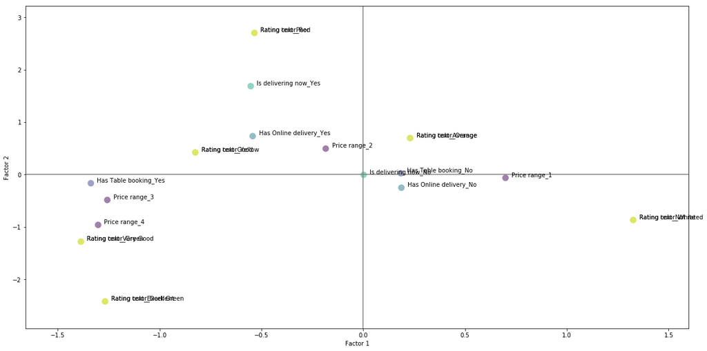

```python
#on affiche chaque point du tableau obtenu précédement (les points sont obtenu par la ligne score factor)
points = mca_info.loc['Factor score'].values
labels = mca_info.columns.values
col=[1,1,1,1,2,2,3,3,4,4,5,5,5,5,5,5,6,6,6,6,6,6] #pour affecter à chaque variable une couleur
plt.figure(figsize=(20,10))
plt.margins(0.1) #intervalles de 0.1 pour l'axe de abscisse
plt.axhline(0, color='grey') #ligne horizontal sur 0
plt.axvline(0, color='grey') #ligne vertical sur 0
plt.xlabel('Factor 1')
plt.ylabel('Factor 2')
plt.scatter(*points, s=120, marker='o', c=col, alpha=.5, linewidths=0)
#l'étoile permet de deballer (unpacking) la variable points qui contient x et y
for label, x, y in zip(labels, *points):
    plt.annotate(label, xy=(x, y), xytext=(x + .03, y + .03)) #pour écrire le nom de la variable au dessus de chaque points
plt.show()
```

On constate un problème : les points des rating_text et ceux de rating_color se supperpose. Cela veut dire qu'il y a une correspondance direct. Cependant, nous n'arrivons pas à les distinguer car les noms se superpose aussi. N'ayant pas trouver de fonction qui permettrai de créer un léger bruit afin de distinguer les points se superposant, nous allons donc faire une fonction jitter qui effectuera cela.

```python
def jitter(values):
    return values + np.random.normal(0, 0.02 * (max(values) - min(values)), len(values))
#pour chaque liste de valeur entré en paramètre la liste de valeur sera retourné avec un bruit créé avec la loi normal

points2=[list(jitter(points[0]))] #on crée le bruit pour les valeurs du 1er facteur (abscisse)
points2.append(list(jitter(points[1]))) #on crée le bruit pour les valeurs du 2ème facteur (ordonnée)
```

```python
def afc():
    labels = mca_info.columns.values
    col=[1,1,1,1,2,2,3,3,4,4,5,5,5,5,5,5,6,6,6,6,6,6]
    plt.figure(figsize=(20,10))
    plt.margins(0.1)
    plt.axhline(0, color='gray')
    plt.axvline(0, color='gray')
    plt.xlabel('Factor 1')
    plt.ylabel('Factor 2')
    plt.scatter(*points2, s=120, marker='o', c=col, alpha=.5, linewidths=0)
    for label, x, y in zip(labels, *points2):
        plt.annotate(label, xy=(x, y), xytext=(x + .03, y + .03))
    plt.show()
```

Retour à l'exercice

### Code : CAH

```python
import scipy.cluster.hierarchy as shc
from sklearn.cluster import AgglomerativeClustering
```

```python
USA=df2.iloc[indexCountry[2]]
#on sélectionne que les restaurants aux USA (la 3ème sous liste de indexCountry contient les indices des restaurant aux USA)
```

```python
df_cah=USA[["Votes","Aggregate rating"]]
#On crée un dataframe ne contenant que les variables du nombre de notes et des appréciations
```

```python
def graph_dendrogram():
    plt.figure(figsize=(10, 7))
    plt.title("Customer Dendrograms")
    shc.dendrogram(shc.linkage(df_cah, method='ward'))
    plt.show()
#on crée le dendrogramme associé aux variables de df_cah
```

```python
def clustering():
    cls = AgglomerativeClustering(n_clusters=3, affinity='euclidean', linkage='ward')
    #on crée le classifieur pour 3 classes avec la distance euclidienne et la méthode de ward (3 a été choisi grâce au dendrogramme)
    cls.fit_predict(df_cah)
    #on affecte à chaque restaurants du dataframe une classe prédit selon le classifieur créé précédement
    plt.figure(figsize=(10, 7))
    plt.scatter(df_cah.iloc[:,0], df_cah.iloc[:,1], c=cls.labels_, cmap='rainbow')
```

Retour à l'exercice

### Code : Régression Linéaire

```python
from sklearn.linear_model import LinearRegression
```

```python
X = df2["Average Cost in dollars"]
Y = df2["Aggregate rating"]
```

```python
lr = LinearRegression()
lr.fit(X.values.reshape(X.shape[0],1),Y) #application de la régression linéaire sur nos données
```

```
LinearRegression(copy_X=True, fit_intercept=True, n_jobs=None,
         normalize=False)
```

```python
def estimateur():
    print("Valeur du coefficient de la variable explicative : "+str(lr.coef_))
    print("Valeur de l'intercept (ordonnée à l'origine) : "+str(lr.intercept_))
```

Retour à l'exercice

### Code : Validation

```python
from sklearn.model_selection import train_test_split
```

```python
X_train,X_test,Y_train,Y_test=train_test_split(X,Y,test_size=0.33,random_state=2)
```

```python
def erreur_quadratique_moyenne(y_pred,y_true):
    return(np.mean(np.square(y_pred-y_true)))
def rac_erreur_quadratique_moyenne(y_pred,y_true): #Racine de l'erreur quadratique moyenne
    return (np.sqrt(np.mean(np.square(y_pred-y_true))))
def erreur_absolue_moyenne(y_pred,y_true):
    return (np.mean(np.abs(y_pred-y_true)))
```

```python
lr=LinearRegression()
lr.fit(X_train.values.reshape(X_train.shape[0],1),Y_train)
y_pred=lr.predict(X_test.values.reshape(X_test.shape[0],1))
y_pred_train=lr.predict(X_train.values.reshape(X_train.shape[0],1))
```

```python
eam_test=erreur_absolue_moyenne(y_pred,Y_test)
raqm_test=rac_erreur_quadratique_moyenne(y_pred,Y_test)
```

```python
raqm_train=rac_erreur_quadratique_moyenne(y_pred_train,Y_train)
eam_train=erreur_absolue_moyenne(y_pred_train,Y_train)
```

```python
def afficheErreurs():
    print("MAE test : {}, RMSE test : {}, MAE train : {}, RMSE train {}".format(eam_test,raqm_test,raqm_train,eam_train))
```

Retour à l'exercice